# Project: Investigate a IMDB Dataset

- Brief Introduction
- Questions to Answer
- Data Wrangling
- Data Cleaning
- Exploratory Data Analysis
- Conclusions
- Resources

## Brief Introduction:

I have selected to work with a dataset from Internet Movie Database (IMDb). IMDb provides crowdsourced and curated data about all aspects of the motion picture industry, at www.imdb.com. IMDb currently contains data on over 3.3 million movies and TV programs. In this dataset it has some preselected rows that will be used in this analysis below (ie. movie popularity, runtime, budget, revenue, director, genres, release date, votes...etc). The dataset contains alittle over 10,000 movies and their associated data.

## Questions to Answer about the Dataset:

We will analyze the IMDb dataset and try to answer some of the questions below. These questions specifically are:

#1) Does budget have any corralation to overall ratings?

#2) How well does movie gross correlate with viewer ratings or awards?

#3) Does runtime affect the rating of a movie (ie. on average do longer movies have better ratings?) ?

#4) What months of the movie release dates had movies with the largest budget to produce?

```python
# importing statements for all of the packages

import sys
import pandas as pd
import numpy as np
import matplotlib.pyplot as plt
import seaborn as sns
% matplotlib inline
```

## Data Wrangling

### Gathering

```python
# Loading the dataset using Pandas CSV read function and printing out a few lines.

df = pd.read_csv('imdb_dataset.csv')
df.head(3)
```

|  | id | imdb_id | popularity | budget | revenue | original_title | cast | homepage | director | tagline | ... | overview | runtime | genres | production_companies | release_date | vote_count | vote_average | release_year | budget_adj | revenue_adj |
| --- | --- | --- | --- | --- | --- | --- | --- | --- | --- | --- | --- | --- | --- | --- | --- | --- | --- | --- | --- | --- | --- |
| 0 | 135397 | tt0369610 | 32.985763 | 150000000 | 1513528810 | Jurassic World | Chris Pratt\|Bryce Dallas Howard\|Irrfan Khan\|Vi... | http://www.jurassicworld.com/ | Colin Trevorrow | The park is open. | ... | Twenty-two years after the events of Jurassic ... | 124 | Action\|Adventure\|Science Fiction\|Thriller | Universal Studios\|Amblin Entertainment\|Legenda... | 6/9/15 | 5562 | 6.5 | 2015 | 1.379999e+08 | 1.392446e+09 |
| 1 | 76341 | tt1392190 | 28.419936 | 150000000 | 378436354 | Mad Max: Fury Road | Tom Hardy\|Charlize Theron\|Hugh Keays-Byrne\|Nic... | http://www.madmaxmovie.com/ | George Miller | What a Lovely Day. | ... | An apocalyptic story set in the furthest reach... | 120 | Action\|Adventure\|Science Fiction\|Thriller | Village Roadshow Pictures\|Kennedy Miller Produ... | 5/13/15 | 6185 | 7.1 | 2015 | 1.379999e+08 | 3.481613e+08 |
| 2 | 262500 | tt2908446 | 13.112507 | 110000000 | 295238201 | Insurgent | Shailene Woodley\|Theo James\|Kate Winslet\|Ansel... | http://www.thedivergentseries.movie/#insurgent | Robert Schwentke | One Choice Can Destroy You | ... | Beatrice Prior must confront her inner demons ... | 119 | Adventure\|Science Fiction\|Thriller | Summit Entertainment\|Mandeville Films\|Red Wago... | 3/18/15 | 2480 | 6.3 | 2015 | 1.012000e+08 | 2.716190e+08 |

3 rows × 21 columns

## Data Cleaning

1) Lets inspect data types and look for instances of missing or possibly errant data.

```python
#What is the overall dimensions of this dataset.
df.shape
```

```
(10866, 21)
```

```python
#Let's see what are the initial data types of the data in each row.
df.info()
```

```
<class 'pandas.core.frame.DataFrame'>
RangeIndex: 10866 entries, 0 to 10865
Data columns (total 21 columns):
id                      10866 non-null int64
imdb_id                 10856 non-null object
popularity              10866 non-null float64
budget                  10866 non-null int64
revenue                 10866 non-null int64
original_title          10866 non-null object
cast                    10790 non-null object
homepage                2936 non-null object
director                10822 non-null object
tagline                 8042 non-null object
keywords                9373 non-null object
overview                10862 non-null object
runtime                 10866 non-null int64
genres                  10843 non-null object
production_companies    9836 non-null object
release_date            10866 non-null object
vote_count              10866 non-null int64
vote_average            10866 non-null float64
release_year            10866 non-null int64
budget_adj              10866 non-null float64
revenue_adj             10866 non-null float64
dtypes: float64(4), int64(6), object(11)
memory usage: 1.7+ MB
```

Seems like we have 21 columns and some are not really going to add much to our analysis (ie. homepage, cast, tagline...etc). We will look to remove them.

2) To answer the questions above, we will need to identify the columms in the dataset that will be the most important to concentrate on and trim out the rest to make the dataset more readable.

Based on the dataType output above, we will choose the following columns to best perform our analysis on:

# id 10866 non-null int64

# popularity 10866 non-null float64

# budget 10866 non-null int64

# revenue 10866 non-null int64

# original_title 10866 non-null object

# runtime 10866 non-null int64

# genres 10843 non-null object

# release_date 10866 non-null object

# vote_count 10866 non-null int64

# vote_average 10866 non-null float64

# release_year 10866 non-null int64

# budget_adj 10866 non-null float64

# revenue_adj 10866 non-null float64

```python
#First print out all available columns:
df_col = df.columns
df_col
```

```
Index(['id', 'imdb_id', 'popularity', 'budget', 'revenue', 'original_title',
       'cast', 'homepage', 'director', 'tagline', 'keywords', 'overview',
       'runtime', 'genres', 'production_companies', 'release_date',
       'vote_count', 'vote_average', 'release_year', 'budget_adj',
       'revenue_adj'],
      dtype='object')
```

As mentioned we have 21 columns. To trim down the dataset we will DROP out EIGHT of the following columns using the .drop() function, as these extra columns don't provide useful data that we can extract with our current Data Science education.

df_drop = ['imdb_id','cast', 'homepage', 'director', 'tagline', 'keywords', 'overview','production_companies', ]

```python
df_drop = ['imdb_id','cast', 'homepage', 'director', 'tagline', 'keywords', 'overview','production_companies']
df.drop(df_drop, axis=1, inplace=True)

#Print a few rows to see if we have the desired columns
df.head(3)
```

|  | id | popularity | budget | revenue | original_title | runtime | genres | release_date | vote_count | vote_average | release_year | budget_adj | revenue_adj |
| --- | --- | --- | --- | --- | --- | --- | --- | --- | --- | --- | --- | --- | --- |
| 0 | 135397 | 32.985763 | 150000000 | 1513528810 | Jurassic World | 124 | Action\|Adventure\|Science Fiction\|Thriller | 6/9/15 | 5562 | 6.5 | 2015 | 1.379999e+08 | 1.392446e+09 |
| 1 | 76341 | 28.419936 | 150000000 | 378436354 | Mad Max: Fury Road | 120 | Action\|Adventure\|Science Fiction\|Thriller | 5/13/15 | 6185 | 7.1 | 2015 | 1.379999e+08 | 3.481613e+08 |
| 2 | 262500 | 13.112507 | 110000000 | 295238201 | Insurgent | 119 | Adventure\|Science Fiction\|Thriller | 3/18/15 | 2480 | 6.3 | 2015 | 1.012000e+08 | 2.716190e+08 |

We are left with 13 columns that we can now see as a whole comfortably.

3) Now let's look at the data types to see if there are any that need to be converted to a more appropriate date type:

```python
df.info()
```

```
<class 'pandas.core.frame.DataFrame'>
RangeIndex: 10866 entries, 0 to 10865
Data columns (total 13 columns):
id                10866 non-null int64
popularity        10866 non-null float64
budget            10866 non-null int64
revenue           10866 non-null int64
original_title    10866 non-null object
runtime           10866 non-null int64
genres            10843 non-null object
release_date      10866 non-null object
vote_count        10866 non-null int64
vote_average      10866 non-null float64
release_year      10866 non-null int64
budget_adj        10866 non-null float64
revenue_adj       10866 non-null float64
dtypes: float64(4), int64(6), object(3)
memory usage: 1.1+ MB
```

As we can see from the list above, the only real columns that needs to be chang are the 3 columns ("release_date"[object], "budget_adj [float64]" and "revenue_adj [float64]") to more appropriate format datatypes. We will use Pandas 'to_datetime' function to change the 'release_date'column type and '.astype()' function for the other two.

```python
 df['release_date'] = pd.to_datetime(df['release_date'])    #change char object to a date format
```

```python
df['budget_adj'] = df['budget_adj'].astype(int)        #change float to int as this represents dollars
df['revenue_adj'] = df['revenue_adj'].astype(int)
```

```python
#Now confirm the changes were made:
df.info();
```

```
<class 'pandas.core.frame.DataFrame'>
RangeIndex: 10866 entries, 0 to 10865
Data columns (total 13 columns):
id                10866 non-null int64
popularity        10866 non-null float64
budget            10866 non-null int64
revenue           10866 non-null int64
original_title    10866 non-null object
runtime           10866 non-null int64
genres            10843 non-null object
release_date      10866 non-null datetime64[ns]
vote_count        10866 non-null int64
vote_average      10866 non-null float64
release_year      10866 non-null int64
budget_adj        10866 non-null int64
revenue_adj       10866 non-null int64
dtypes: datetime64[ns](1), float64(2), int64(8), object(2)
memory usage: 1.1+ MB
```

```python
for i, v in enumerate(df.columns):
    print(i, v)
```

```
0 id
1 popularity
2 budget
3 revenue
4 original_title
5 runtime
6 genres
7 release_date
8 vote_count
9 vote_average
10 release_year
11 budget_adj
12 revenue_adj
```

```python
df.head()
```

|  | id | popularity | budget | revenue | original_title | runtime | genres | release_date | vote_count | vote_average | release_year | budget_adj | revenue_adj |
| --- | --- | --- | --- | --- | --- | --- | --- | --- | --- | --- | --- | --- | --- |
| 0 | 135397 | 32.985763 | 150000000 | 1513528810 | Jurassic World | 124 | Action\|Adventure\|Science Fiction\|Thriller | 2015-06-09 | 5562 | 6.5 | 2015 | 137999939 | 1392445892 |
| 1 | 76341 | 28.419936 | 150000000 | 378436354 | Mad Max: Fury Road | 120 | Action\|Adventure\|Science Fiction\|Thriller | 2015-05-13 | 6185 | 7.1 | 2015 | 137999939 | 348161292 |
| 2 | 262500 | 13.112507 | 110000000 | 295238201 | Insurgent | 119 | Adventure\|Science Fiction\|Thriller | 2015-03-18 | 2480 | 6.3 | 2015 | 101199955 | 271619025 |
| 3 | 140607 | 11.173104 | 200000000 | 2068178225 | Star Wars: The Force Awakens | 136 | Action\|Adventure\|Science Fiction\|Fantasy | 2015-12-15 | 5292 | 7.5 | 2015 | 183999919 | 1902723129 |
| 4 | 168259 | 9.335014 | 190000000 | 1506249360 | Furious 7 | 137 | Action\|Crime\|Thriller | 2015-04-01 | 2947 | 7.3 | 2015 | 174799923 | 1385748801 |

4) Lets now look if there are any reduction of the row count.

Just looking at near the bottom of the dataset we notice there are many rows with 'zero' entries in the either Budget, Revenue, or Both.

Not sure why this is but looking at the year can give us a clue that they didn't have proper data back in the early 60's

```python
df.tail(10)
```

|  | id | popularity | budget | revenue | original_title | runtime | genres | release_date | vote_count | vote_average | release_year | budget_adj | revenue_adj |
| --- | --- | --- | --- | --- | --- | --- | --- | --- | --- | --- | --- | --- | --- |
| 10856 | 20277 | 0.140934 | 0 | 0 | The Ugly Dachshund | 93 | Comedy\|Drama\|Family | 2066-02-16 | 14 | 5.7 | 1966 | 0 | 0 |
| 10857 | 5921 | 0.131378 | 0 | 0 | Nevada Smith | 128 | Action\|Western | 2066-06-10 | 10 | 5.9 | 1966 | 0 | 0 |
| 10858 | 31918 | 0.317824 | 0 | 0 | The Russians Are Coming, The Russians Are Coming | 126 | Comedy\|War | 2066-05-25 | 11 | 5.5 | 1966 | 0 | 0 |
| 10859 | 20620 | 0.089072 | 0 | 0 | Seconds | 100 | Mystery\|Science Fiction\|Thriller\|Drama | 2066-10-05 | 22 | 6.6 | 1966 | 0 | 0 |
| 10860 | 5060 | 0.087034 | 0 | 0 | Carry On Screaming! | 87 | Comedy | 2066-05-20 | 13 | 7.0 | 1966 | 0 | 0 |
| 10861 | 21 | 0.080598 | 0 | 0 | The Endless Summer | 95 | Documentary | 2066-06-15 | 11 | 7.4 | 1966 | 0 | 0 |
| 10862 | 20379 | 0.065543 | 0 | 0 | Grand Prix | 176 | Action\|Adventure\|Drama | 2066-12-21 | 20 | 5.7 | 1966 | 0 | 0 |
| 10863 | 39768 | 0.065141 | 0 | 0 | Beregis Avtomobilya | 94 | Mystery\|Comedy | 2066-01-01 | 11 | 6.5 | 1966 | 0 | 0 |
| 10864 | 21449 | 0.064317 | 0 | 0 | What's Up, Tiger Lily? | 80 | Action\|Comedy | 2066-11-02 | 22 | 5.4 | 1966 | 0 | 0 |
| 10865 | 22293 | 0.035919 | 19000 | 0 | Manos: The Hands of Fate | 74 | Horror | 2066-11-15 | 15 | 1.5 | 1966 | 127642 | 0 |

We see we have Zero's as entries, but let's see if we have any complete NULL rows?

```python
df[df.isnull().any(axis=1)].shape
```

```
(23, 13)
```

Seems like we have 23 rows with NULL or Zero entries. Lets drops these!

```python
df[df.isnull().any(axis=1)].count()
```

```
id                23
popularity        23
budget            23
revenue           23
original_title    23
runtime           23
genres             0
release_date      23
vote_count        23
vote_average      23
release_year      23
budget_adj        23
revenue_adj       23
dtype: int64
```

```python
#Drop rows with any null values:
df = df.dropna()
df.shape
```

```
(10843, 13)
```

Notice after we dropped any rows that contain "null's" we dropped 23 rows (10866 -> 10843 rows). So final condensed dataset now contains 13 columns and 10843 rows.

5) Now let's see if our new dataset has any duplicates?

```python
#Check for duplicate rows
df[df.duplicated()]
```

|  | id | popularity | budget | revenue | original_title | runtime | genres | release_date | vote_count | vote_average | release_year | budget_adj | revenue_adj |
| --- | --- | --- | --- | --- | --- | --- | --- | --- | --- | --- | --- | --- | --- |
| 2090 | 42194 | 0.59643 | 30000000 | 967000 | TEKKEN | 92 | Crime\|Drama\|Action\|Thriller\|Science Fiction | 2010-03-20 | 110 | 5.0 | 2010 | 30000000 | 967000 |

Seems we have 1 duplicate row so we will use 'drop_duplicate' function to drop it!

```python
df.drop_duplicates(inplace=True)
df.shape
```

```
(10842, 13)
```

Notice now after we dropped the duped row we dropped 1 row (10843 -> 10842 rows)

So after some basic analysis and cleaning, datatype editing, we have a 'cleaned' dataset that has 13 columns and 10842 rows to start our Exploratory stage of our analysis.

###### #

###### #

## Exploratory Data Analysis

### Research Question 1:

1) Does budget spent to make a movie have any corralation to overall ratings?

To answer this question we need make sure the dataset is populated with 'meaningful' data. Let us see if any of the variable columns has '0' for either of the 'budget', 'revenue', 'budget_adj', and 'revenue_adj' columns so we can see if we can drop those from the analysis of this question. While a zero in either of these fields (ie. 0 dollars spent and/or made by a movie company) is a valid entry for any movie ecomonics it just isn't a practicle measurement to consider that a film company spent 0 dollars or made $0 on a movie. To this end, we will go through a series of filtering out any zeros found in each column 1) budget, 2) revenue, 3) budget_adj and finally 4) revenue_adj in the next few code fields below.

```python
df_2 = df[df.budget != 0]
df_2.shape
```

```
(5168, 13)
```

```python
df_3 = df_2[df_2.revenue != 0]
df_3.shape
```

```
(3854, 13)
```

```python
df_4 = df_3[df_3.budget_adj != 0]
df_4.shape
```

```
(3853, 13)
```

```python
df_5 = df_4[df_4.revenue_adj != 0]
df_5.shape
```

```
(3853, 13)
```

WOW! We can see there was ALOT of missing data for these 4 columns as we seemed to reduce our row count from 10,842 down to 3,853 (nearly ~7,000 rows or 64% rows dropped). Although this is over half the original dataset we should still have enough data points to make some meaningful analysis. We will comment if this is not the case.

Lets look at the info on the 'vote_average' columm to see if there is a good distribution

```python
df_5['vote_average'].describe()
```

```
count    3853.000000
mean        6.168388
std         0.794900
min         2.200000
25%         5.700000
50%         6.200000
75%         6.700000
max         8.400000
Name: vote_average, dtype: float64
```

From the above describe function we can see a mean of 6.17 and a good distribution above ~5.0 rating. However, just to make sure let's plot a histgram of 'vote_average' to confirm we are seeing this:

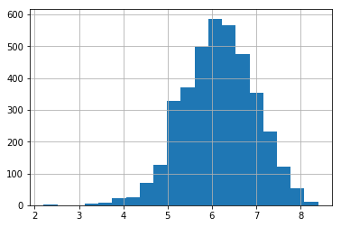

```python
df_5['vote_average'].hist(bins=20);
```

This histgram looks good with an even distribution with right shift and no skew, and is centered around 6 star rating. But what would have been the difference if we didn't filter out thoe 7000 rows and did the histgram on the full 10000+ row original dataset (df) ? Lets' see:

```python
df['vote_average'].mean()        #mean taken on dataset with ~ 10,000 data points
```

```
5.9740638258623866
```

```python
df_5['vote_average'].mean()      #mean taken on dataset with ~ 4,000 data points
```

```
6.168388268881392
```

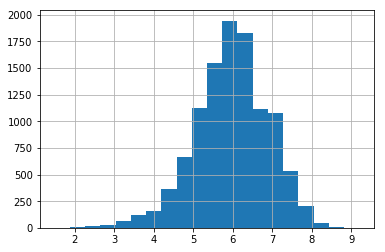

```python
df['vote_average'].hist(bins=20);
```

From the above, we can see the 'vote_average' mean didn't move much (~3% increase) when we filtered out 7000 rows (from df) down to 4000 (df_5) and the average rating is still around 6 stars.

But this doesn't truly answer our question if we want to see if the rating actually increases or descreases with respect to the independent variable of budget. To do this we will need to plot something like a SCATTER PLOT with Budget on the x-axis and see how Vote_average on the y-axis is affected. And since we already filtered our list down we do the plot using the filtered df_5 dataset.

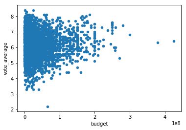

```python
#Scatterplot on how vote_average w.r.t. budget (in $100 million).

df_5.plot(x='budget', y='vote_average', kind='scatter');
```

[figure not shown]

Hmm, looking at this scatterplot above we can see a huge concentration in the lower budget (<$100 million)

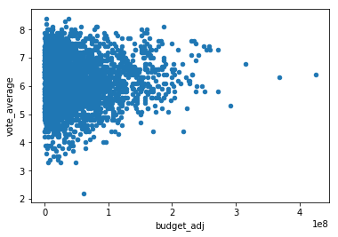

```python
#Scatterplot on how vote_average w.r.t. budget_adjusted (in $100 million).

df_5.plot(x='budget_adj', y='vote_average', kind='scatter');
```

Noticing this mass concentration near low (or zero) budget line I think we need to filter out some low (non-zero) entries as this might give us back feel of the data. Let us see what is the lowest value for Adjusted Budget and maybe that will help us figure out which level to filter out on.

```python
df_5['budget_adj'].describe();
```

[figure not shown]

So we see there is at least one entry (min) with a budget of '1 dollar' but the mean is closer to 44 million dollars and the 25% level is way up near 13 million so I think we have some low budgets that might mess up our analysis if we move forward with our data as is.

To this end we will filter out an arbitrary level of budgets over 10000 dollars which should be reasonable and make out assumption of it takes more then 10000 dollars to make a movie and these rows filtered out are errors due to data entry.

Note: we don't want to raise the filter to high (ie. $1,000,000) as this might circumvent the question what we are trying to answer (in a sense, do you have to spend alot of money to make a good movie that recieves a high rating?)

```python
#Applying to filter out Adjusted Budget under $10,000
df_5.query('budget_adj < 10000').count()
```

```
id                24
popularity        24
budget            24
revenue           24
original_title    24
runtime           24
genres            24
release_date      24
vote_count        24
vote_average      24
release_year      24
budget_adj        24
revenue_adj       24
dtype: int64
```

We see we have found 24 movies with adjusted budgets under 10,000. Let's filter out these and see where our new MIN is.

```python
df_5 = df_5[df_5.budget_adj > 10000]
```

```python
df_5['budget_adj'].describe();
```

[figure not shown]

```python
df_5.shape
```

```
(3829, 13)
```

After filtering out these 24 rows we now have 3829 entries in our df_5 dataset. We can also see after looking at the describe out min value has bumped up to ~ 16K dollors which sounds more respectable for a movie budget.

Now, lets run the scatterplot on this new df_5 dataset to see if we have any changes.

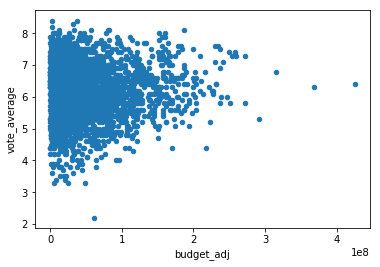

```python
df_5.plot(x='budget_adj', y='vote_average', kind='scatter');
```

[figure not shown]

As a matter of fact we can see that, at least in this comparison, some of the highest ratings (7-8+) (B in the cell above) seem to indicate that a small budget (10,000-50 million) can produce a highest rated movie then movies around the mean budget_adj spent (A in the cell above).

###### #

###### #

### Research Question 2:

# How well does movie viewer ratings correlate with gross revenue ?

So for this question, we are asking somewhat in the opposite manner and seeing when people rate a movie very high does it tend to produce a promotion effect and more people go see it and in turn produce a higher revenue? Lets see.

This time we will filter for revenues (adjusted) to be over 1 million dollars to make is a somewhat reasonable analysis as movies these days have global reach and we want to do analysis on movies that have alot of votes. To this end we are doing another filter (df_6) for revenues above $1 million. In this plot our Independent variable is now 'vote_average' and our Dependent var is 'Revenue_adj'.

```python
#Apply to filter out movies that received revenue less then $1 million.
df_6 = df_5[df_5.revenue_adj > 1000000]
```

```python
df_6.describe()
```

|  | id | popularity | budget | revenue | runtime | vote_count | vote_average | release_year | budget_adj | revenue_adj |
| --- | --- | --- | --- | --- | --- | --- | --- | --- | --- | --- |
| count | 3605.000000 | 3605.000000 | 3.605000e+03 | 3.605000e+03 | 3605.000000 | 3605.000000 | 3605.000000 | 3605.000000 | 3.605000e+03 | 3.605000e+03 |
| mean | 38360.056311 | 1.242438 | 3.925002e+07 | 1.150709e+08 | 109.790014 | 558.731484 | 6.190374 | 2000.929542 | 4.671833e+07 | 1.464431e+08 |
| std | 66300.785150 | 1.510300 | 4.279160e+07 | 1.801986e+08 | 19.647815 | 901.216228 | 0.785615 | 11.419653 | 4.517040e+07 | 2.203512e+08 |
| min | 5.000000 | 0.001117 | 1.000000e+04 | 5.027580e+05 | 26.000000 | 10.000000 | 3.300000 | 1960.000000 | 1.577500e+04 | 1.001273e+06 |
| 25% | 5185.000000 | 0.492637 | 1.100000e+07 | 1.783487e+07 | 96.000000 | 81.000000 | 5.700000 | 1995.000000 | 1.540958e+07 | 2.418892e+07 |
| 50% | 11001.000000 | 0.859276 | 2.500000e+07 | 5.124940e+07 | 106.000000 | 230.000000 | 6.200000 | 2004.000000 | 3.245007e+07 | 6.956391e+07 |
| 75% | 36643.000000 | 1.432839 | 5.000000e+07 | 1.344024e+08 | 120.000000 | 615.000000 | 6.700000 | 2010.000000 | 6.339774e+07 | 1.750382e+08 |
| max | 417859.000000 | 32.985763 | 4.250000e+08 | 2.781506e+09 | 248.000000 | 9767.000000 | 8.400000 | 2015.000000 | 4.250000e+08 | 2.827124e+09 |

So after filting out movies with more then $1 million we have 3605 rows to work our analysis with.

Let's now do a SCATTERPLOT of Adjusted Revenue vs. Average Votes.

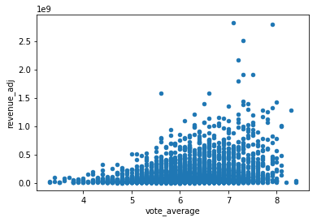

```python
df_6.plot(x='vote_average', y='revenue_adj', kind='scatter');
```

[figure not shown]

As we can see there is SOME corralation in the early stages of the votes and starts to rise for a few movie points (the green arrows in C in cell above) but in general the concentration of revenue is under 0.5 billion for some of the highest rated movies (A) even thou there were some outlair ratings that correlated with extreme revenues (B).

The movies here (B) might be the animation movies or some high production cast that made if such a hit at the box office but in general doesn't seem to be the norm for the average rating.

In general, we have some correlation when the rating is low (4-6) but then tends to go all over the map as we move above a vote rating of 6. So, in conclusion we have some correlation but not strong to make any concrete predictions.

###### #

###### #

### Research Question 3:

# Does runtime affect the rating of a movie (ie. on average do longer movies have better ratings?) ?

Before we can answer this question, we need to see the bigger picture of how the runtimes are distributed w.r.t. the rest of the data points. For this question, we will go back and use the the original dataset (df) and work from there.

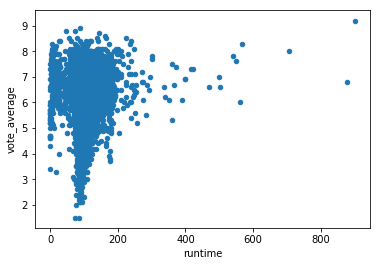

```python
#Plot a Scatterplot of the average votes vs. the runtime.
df.plot(x='runtime', y='vote_average', kind='scatter');
```

```python
#What the mean value of the Runtime?
df['runtime'].mean()
```

```
102.1384430916805
```

```python
df['runtime'].describe()
```

```
count    10842.000000
mean       102.138443
std         31.294612
min          0.000000
25%         90.000000
50%         99.000000
75%        111.000000
max        900.000000
Name: runtime, dtype: float64
```

We can see from the describe output we have 10842 data points but some big outlairs at the min/max extremes (one at '0' and '900' mins runtime). Does this make sense to keep movies that were in the theatre of 0 mins or 900 mins. I think not, so lets' trim the dataset on some boundaries. Let's see how many movies have 900 mins, '0' mins, less then 20 mins, and over 240 mins.

```python
df[df['runtime'] == 900]   #only 1 '"movie", looks like a 15 hour T.V. documentary, so this wouldn't be in the theatre.
```

|  | id | popularity | budget | revenue | original_title | runtime | genres | release_date | vote_count | vote_average | release_year | budget_adj | revenue_adj |
| --- | --- | --- | --- | --- | --- | --- | --- | --- | --- | --- | --- | --- | --- |
| 3894 | 125336 | 0.006925 | 0 | 0 | The Story of Film: An Odyssey | 900 | Documentary | 2011-09-03 | 14 | 9.2 | 2011 | 0 | 0 |

```python
#Find how many movies have runtime less then 20 minutes
df[df.runtime < 20].describe()
```

|  | id | popularity | budget | revenue | runtime | vote_count | vote_average | release_year | budget_adj | revenue_adj |
| --- | --- | --- | --- | --- | --- | --- | --- | --- | --- | --- |
| count | 177.000000 | 177.000000 | 1.770000e+02 | 177.000000 | 177.000000 | 177.000000 | 177.000000 | 177.000000 | 1.770000e+02 | 177.000000 |
| mean | 125536.214689 | 0.342239 | 8.945115e+04 | 0.028249 | 6.785311 | 50.960452 | 6.644068 | 2007.237288 | 1.058032e+05 | 0.028249 |
| std | 113993.961681 | 0.679425 | 5.511416e+05 | 0.375823 | 5.019191 | 74.074315 | 0.936253 | 9.569137 | 6.513814e+05 | 0.375823 |
| min | 3171.000000 | 0.002757 | 0.000000e+00 | 0.000000 | 0.000000 | 10.000000 | 3.300000 | 1963.000000 | 0.000000e+00 | 0.000000 |
| 25% | 28004.000000 | 0.088877 | 0.000000e+00 | 0.000000 | 4.000000 | 13.000000 | 6.000000 | 2005.000000 | 0.000000e+00 | 0.000000 |
| 50% | 76535.000000 | 0.206849 | 0.000000e+00 | 0.000000 | 6.000000 | 23.000000 | 6.800000 | 2010.000000 | 0.000000e+00 | 0.000000 |
| 75% | 224815.000000 | 0.407520 | 0.000000e+00 | 0.000000 | 10.000000 | 51.000000 | 7.300000 | 2013.000000 | 0.000000e+00 | 0.000000 |
| max | 370687.000000 | 8.411577 | 6.000000e+06 | 5.000000 | 19.000000 | 507.000000 | 8.300000 | 2015.000000 | 7.273568e+06 | 5.000000 |

```python
#Find how many movies have runtime over 240 minutes.

df[df.runtime > 240].describe()
```

|  | id | popularity | budget | revenue | runtime | vote_count | vote_average | release_year | budget_adj | revenue_adj |
| --- | --- | --- | --- | --- | --- | --- | --- | --- | --- | --- |
| count | 42.000000 | 42.000000 | 4.200000e+01 | 4.200000e+01 | 42.000000 | 42.000000 | 42.000000 | 42.000000 | 4.200000e+01 | 4.200000e+01 |
| mean | 155117.761905 | 0.266421 | 8.264643e+06 | 4.967173e+06 | 381.380952 | 41.642857 | 6.835714 | 2003.000000 | 1.355618e+07 | 1.437463e+07 |
| std | 118391.095256 | 0.250368 | 2.170049e+07 | 2.127036e+07 | 160.395540 | 52.134826 | 0.822792 | 10.162101 | 3.989852e+07 | 6.726724e+07 |
| min | 876.000000 | 0.000065 | 0.000000e+00 | 0.000000e+00 | 242.000000 | 10.000000 | 5.200000 | 1963.000000 | 0.000000e+00 | 0.000000e+00 |
| 25% | 42391.500000 | 0.095589 | 0.000000e+00 | 0.000000e+00 | 270.000000 | 17.750000 | 6.325000 | 1999.250000 | 0.000000e+00 | 0.000000e+00 |
| 50% | 144890.500000 | 0.193319 | 0.000000e+00 | 0.000000e+00 | 337.000000 | 28.000000 | 6.750000 | 2004.000000 | 0.000000e+00 | 0.000000e+00 |
| 75% | 216618.750000 | 0.393680 | 0.000000e+00 | 0.000000e+00 | 420.000000 | 42.500000 | 7.300000 | 2010.750000 | 0.000000e+00 | 0.000000e+00 |
| max | 414419.000000 | 1.180484 | 1.200000e+08 | 1.250000e+08 | 900.000000 | 313.000000 | 9.200000 | 2015.000000 | 2.215444e+08 | 4.111904e+08 |

Note: We are choosing 240 mins as the upper limit of our analysis because this seems to be a reasonable length of a movie to be less then this (4 hours) for a movie that would show in the theatre. Do you know alot of movies that you would sit in a theatre to watch for 4 hours???.. me neither!

[figure not shown]

Based on the above analysis we can see:

- There are 42 movies that are over 4 hours (240 mins)
- There are 177 movies that are under 20 mins (20 mins)